# Exploring damEffect on SWA with RF model

Matt Webster

2026-07-09

## **NOTE**

## **RF EXPLORATION ON HOLD UNTIL FURTHER NOTICE**

## 07.14.2026

## Pursue hurdle model with hierarchical linear mixed effects framework

## —-

## —-

## —-

## —-

The purpose of this script is to explore the effect of beaver dams on surface water area, relative to local geomorphology, and contributing drainage area. This modeling focuses solely on late summer months; August & September.

This particular iteration explores the use of random forest models to assess importance of dam_m and damDensity as predictors of surface water area.

## —-

## Data from USGS LBV Guston Coulee gage, near Saco, MT:

## Late Summer Flow Conditions

## 2019:

Moderate August with peak in September

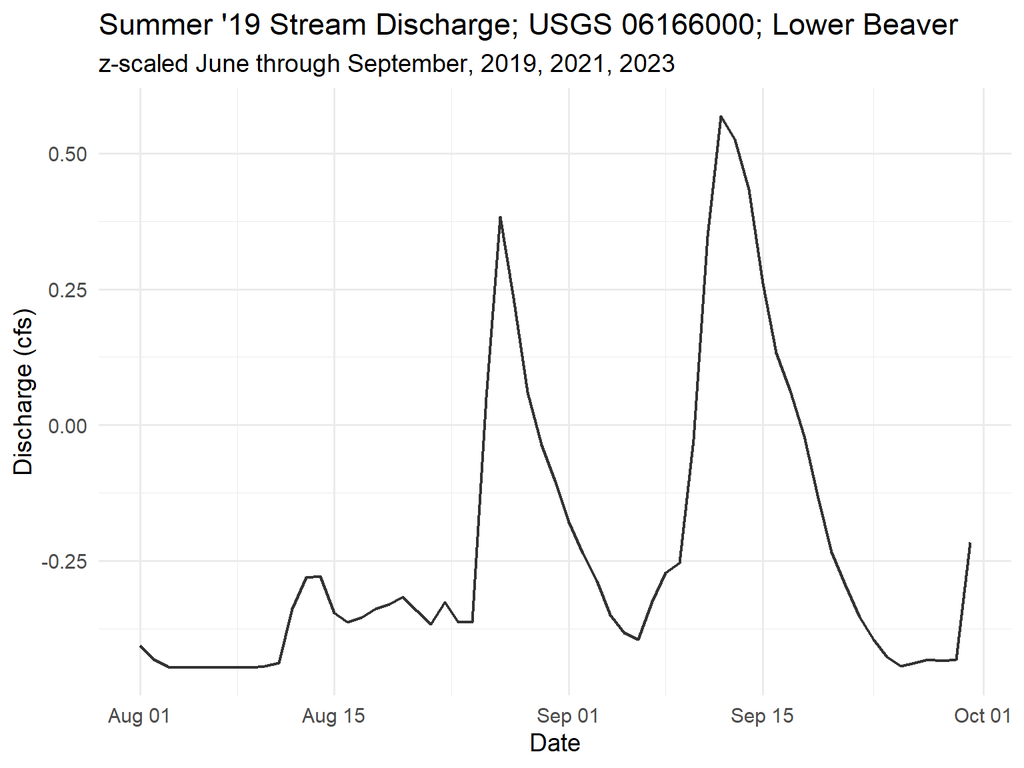

## 2021:

Low flow conditions throughout the summer season. Part of 3 year sustained drought conditions (2020, 2021, 2022).

Gage recorded no flow during August & September

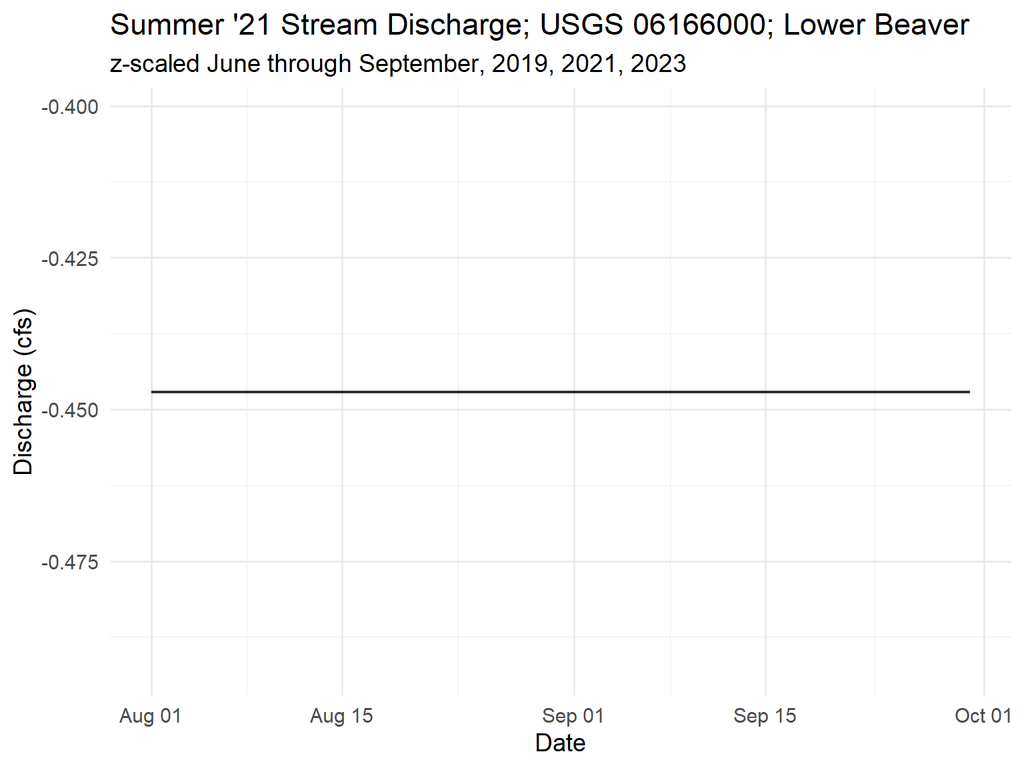

## 2023:

Moderate to low August & September flows; after early season extreme flooding.

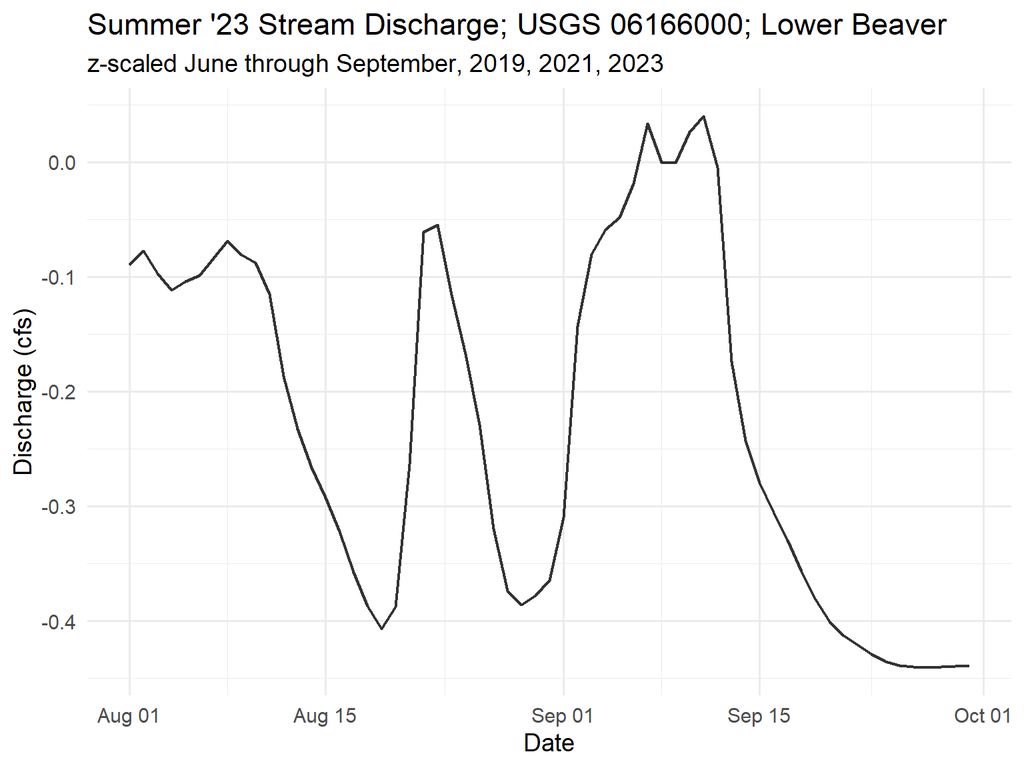

## GEE-derived data for each stream:

Currently each incoming data frame is of the following structure:

Where:

```
- clusterID_seq = dammed/undammed sample pair ID
- window_type = whether a sample window is 'dammed' or 'undammed'
- watershed = watershed identifier (e.g., "BRZ" = Brazil Ck)
- year = year
- window_length = length (m) of stream flow line within sample window
- catchment_km2 = contributing catchment area/upstream drainage area (km^2)
- riparian_area_m2 = riparian area (m^2) of sample window; 2-m vertical
  buffer from DEM low point (stream flow line)
- TO = mean topographic openness across window
- p_window: avg dam detection prob for target window; see CP Ch1
- f_window: avg dam false positive prob for target window; see CP Ch1
- beav_count_all: all unique detected dams
- beav_count_conf: unique confidently detected dams
- anthro_count: all unique detected anthropogenic dams
- isAnthro: National Wetland Inventory (NWI) "dyked/impounded"
- Nhat = estimated dam count within sample window
  - ...= beav_count_all/(p_window(1-f_window)  [McCallum 2005]
- TO_mean = mean topographic openness across window
- time_period = 2wk interval 06/01 - 09/30
- SWA = surface water area (m^2) for window during time (t)
- t = time (t) {same as time_period}
```

## —-

## —-

**Relative flow data.**

NOTE: currently this represents data from the USGS Guston Coulee gage that has been z-standardized over the current data acquisition range (June-Sept; 2019, 2021, 2023).

Then, for each 2-week survey time period (1:8), the average relative flow $[mean(zFlow)]$ was computed, and added as a data column. IT IS ASSUMED that this flow data is representative of the RELATIVE flow pattern experienced throughout the study area during this time.

Add relFlow data:

## —-

Whittle data to just what you want to fit the model with:

```
clusterID_seq
SWA
dam_m
TO
riparian_area_m2
catchment_km2
stream
year_id
sampleEvent_new
```

```
## 'data.frame':    2445 obs. of  9 variables:
##  $ SWA             : num  106.7 0 94.6 2382 66.7 ...
##  $ dam_m           : num  1 1 1 1 0 0 0 0 1 1 ...
##  $ TO              : num  34.2 34.2 34.2 34.2 35.7 ...
##  $ riparian_area_m2: num  2678 2678 2678 2678 2766 ...
##  $ catchment_km2   : num  1394 1394 1394 1394 1391 ...
##  $ stream          : Factor w/ 6 levels "1","2","3","4",..: 6 6 6 6 6 6 6 6 6 6 ...
##  $ year_id         : Factor w/ 3 levels "1","2","3": 1 1 1 1 1 1 1 1 1 1 ...
##  $ sampleEvent_new : Factor w/ 12 levels "1","2","3","4",..: 1 2 3 4 1 2 3 4 1 2 ...
##  $ clusterID_seq   : Factor w/ 72 levels "1","2","3","4",..: 1 1 1 1 1 1 1 1 3 3 ...
```

## RF MODELING

Find any ‘NA’ data, and impute values using median/proximity

```
## [1] 0
```

Great! No NA values means no need for data imputation prior to modeling.

Fit RF model to data:

```
## Ranger result
##
## Call:
##  ranger(formula = SWA ~ ., data = RF_dat, importance = "permutation",      num.trees = 500)
##
## Type:                             Regression
## Number of trees:                  500
## Sample size:                      2445
## Number of independent variables:  8
## Mtry:                             2
## Target node size:                 5
## Variable importance mode:         permutation
## Splitrule:                        variance
## OOB prediction error (MSE):       577105.1
## R squared (OOB):                  0.7599356
```

```
## [1] 759.6744
```

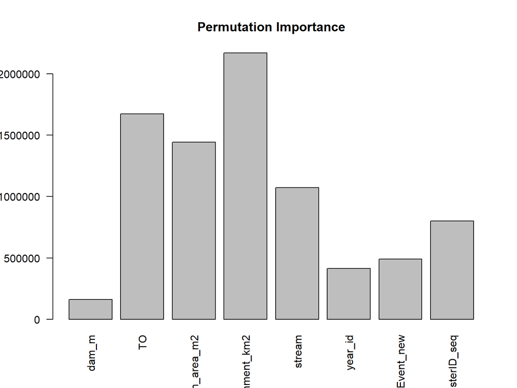

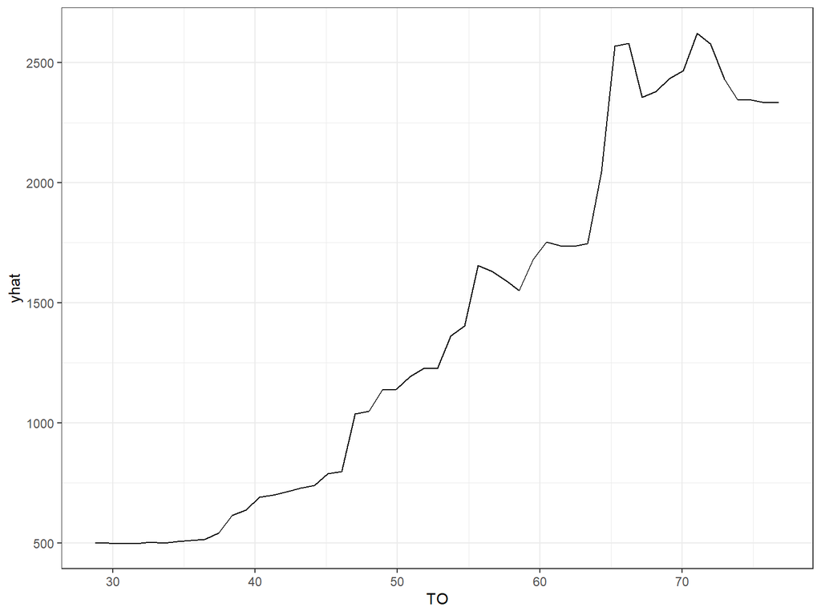

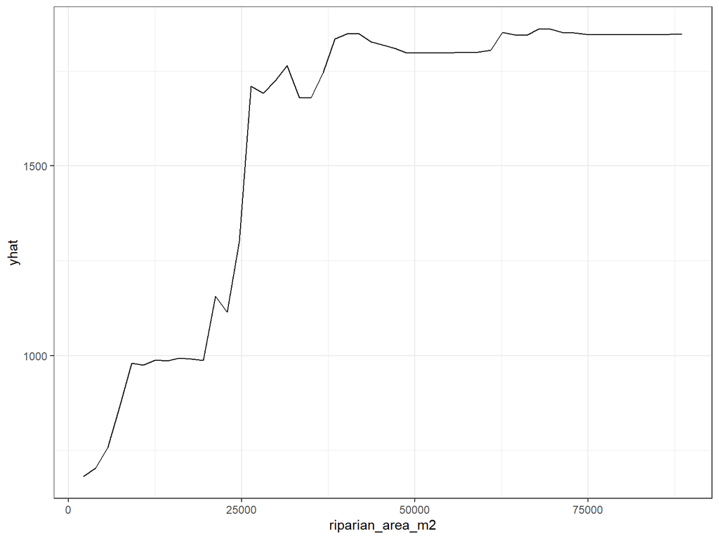

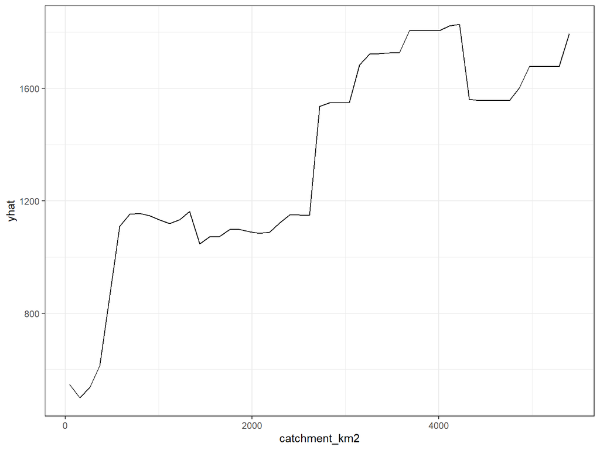

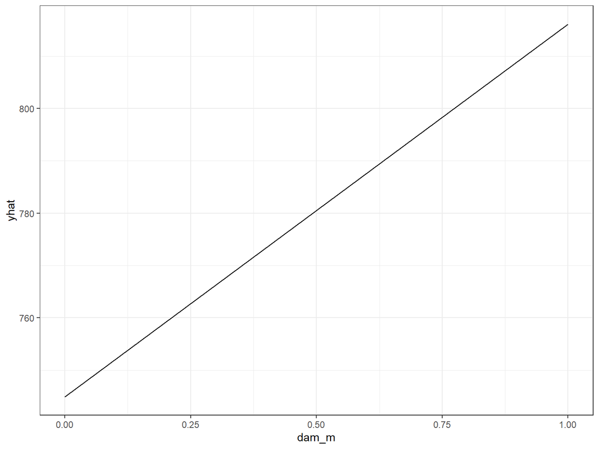

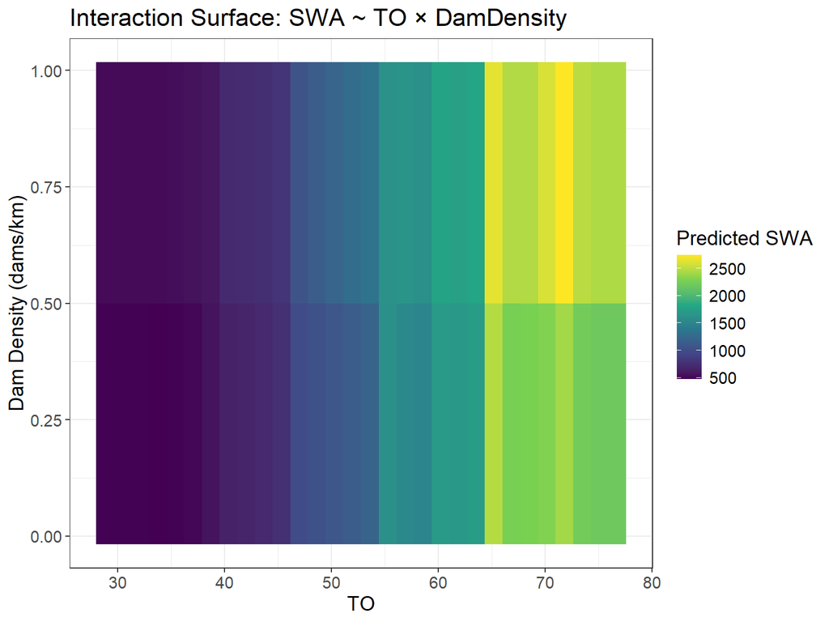

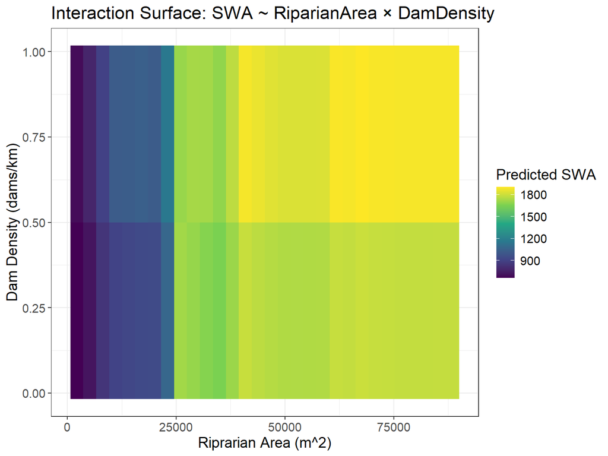

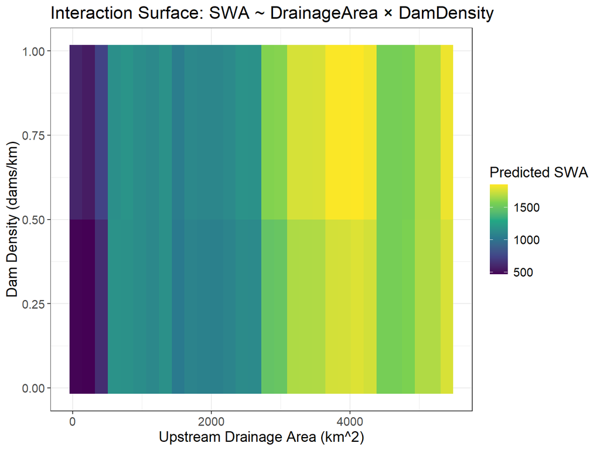

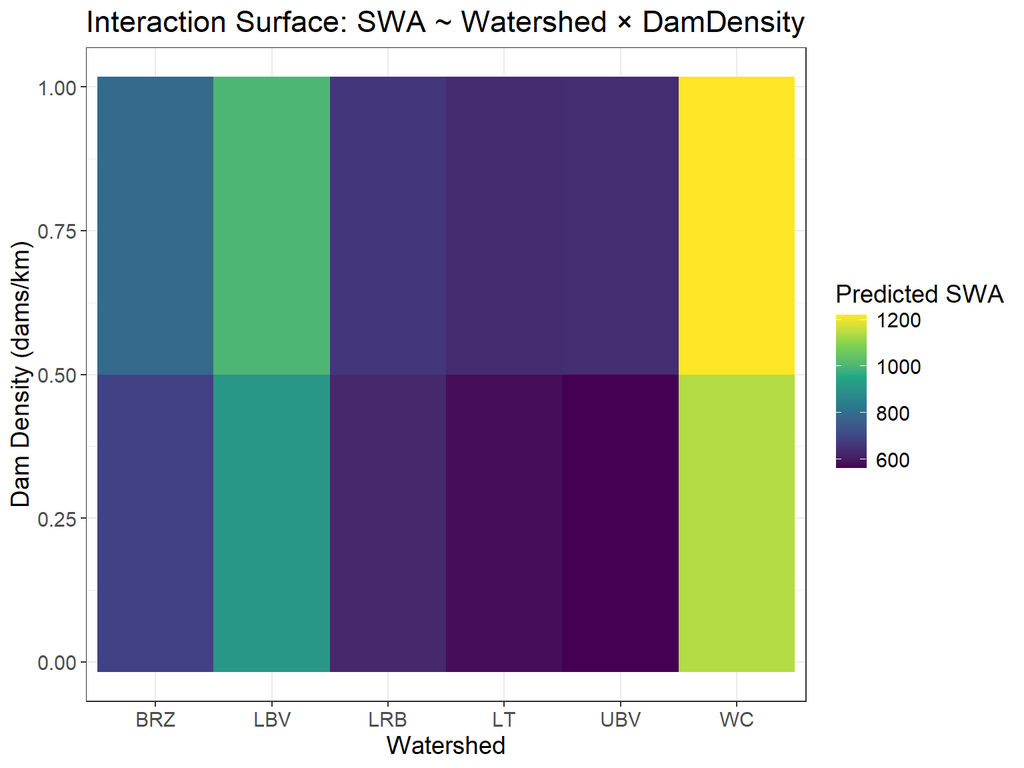

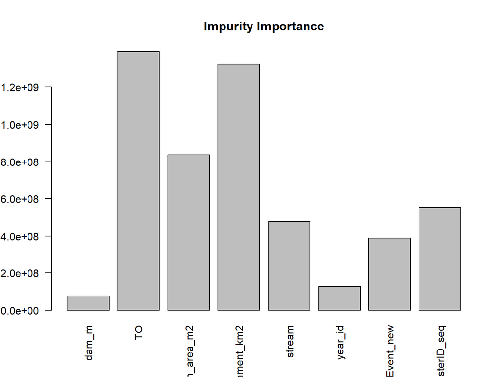